# Machine-Learning-vol.05-正則化

## 5.1 過学習の基礎知識

**正則化**とは､**モデルの複雑さを抑えることで過学習を防ぐテクニック**です｡前回扱った多項式回帰は､それまでの線形回帰と比べて**モデルが複雑になりやすい**という欠点があり､過学習を起こす可能性が高くなっていました｡そこで､過学習を防ぐ正則化が活躍します｡ところで､正則化の手法には代表的なものが3種類あり､それぞれ **Ridge** ､ **LASSO** ､ **ElasticNet** といいます｡これらの手法はややコンセプトが異なっており､それを使い分けられるようになるところまでが本章の目標です｡

[figure not shown]

まず初めに､**正則化が対処する過学習というもの自体についての理解を深めましょう**｡ここを押さえることによって､このあと解説する正則化のコンセプトをより深く理解できるようになります｡

### 5.1.1 過学習とは（復習）

重回帰分析の章で触れましたが､過学習とは**学習データには正確な予測ができるけど､将来のデータに対してはそれほどでもないというモデルの状態**のことです｡trainデータにしかない､本質的でない特徴に過剰に適合してしまった結果､**汎化性能**を損なってしまっています｡これでは､将来の予測をさせる上では信頼できません｡

[figure not shown]

### 5.1.2 誤差を生む要因

過学習をしてしまったモデルは未知のサンプルへの予測誤差が大きいわけですが､このような予測誤差を生む要因は大きく3つに分けられます｡それが､**バイアス**と**バリアンス**と**ノイズ**であり､モデルの誤差に関して以下の方程式が成り立ちます｡これを踏まえると､正則化の役割は**バリアンスを抑えることで､バイアスとバリアンスのバランスを調整すること**だといえます｡

[figure not shown]

#### バイアス (Bias)

バイアスとは､**モデルの表現力不足によって生じる誤差**です｡たとえば､3次関数に従ったデータを線形回帰したときは**バイアスが大きい（未学習）**といえます｡表現力の低いモデルを利用しているために､**意味のあるパターンを拾いきれていない**のです｡

#### バリアンス (Variance)

バリアンスとは､**trainデータに過剰適合することによって生じる誤差**です｡たとえば､3次関数に従ったデータを7次関数で多項式回帰したときは**バリアンスが大きい（過学習）**といえます｡表現力が高すぎるモデルを利用しているために､**trainデータにしかないパターンを拾ってしまっている**のです｡

#### ノイズ (Noise)

ノイズとは､**データに混入している本質的でない情報です**｡ノイズは本質的な情報と混ざってデータ中に存在しており､両者を区別することができません｡そのため､**機械学習の手法を用いても取り除くことができません**｡

### 5.1.3 過学習の原因

**バリアンスを高くして､過学習を引き起こしてしまう原因**を2つ紹介します｡これらを防ぐことで､バリアンスを抑えることができます｡

[figure not shown]

#### 原因1. 重みパラメータの値が極端になっている

原因のひとつめは､**重みパラメータの絶対値が極端に大きくなっていること**です｡なぜなら､**極端なパラメータはモデルを複雑な関数にしてしまう**ためです｡例えば､多項式の場合であれば､グラフをぐにゃぐにゃに曲げてしまいます｡なので､**重みパラメータの値を平易に保つことができればモデルが平易でなめらかな形になり､バリアンスは抑えられます**｡

#### 原因2. サンプル数に対して説明変数が多すぎる

また､**説明変数が多すぎること**も過学習を引き起こす原因のひとつです｡説明変数が多くなると､**調整すべきパラメータの数が増えてしまったり､多重共線性の可能性も高まる**ために過学習が起こりやすくなります｡一般に､**学習すべきパラメータが増えると､学習により多くのサンプルを必要とするようになります**｡また､**線形モデルの場合はパラメータの数は説明変数の数にほぼ一致するので**､説明変数を減らすことで改善されます｡多項式の場合は次数を落としてもパラメータを減らせます｡なので､**説明変数を減らせば､あるいは多項式の次数を落とせばバリアンスは抑えられます**｡

## 5.2 正則化のアルゴリズム

正則化のアルゴリズムは､**上記の2つの原因への対応策**になっています｡**重みパラメータの値を平易なものにし､手法によっては説明変数を自動的に減らしてもくれます**｡まずは､あらゆる正則化手法に共通する､**重みパラメータへの制限**について解説します｡

### 5.2.1 重みベクトル $\boldsymbol{w}$ の大きさ制限

正則化手法の共通方針は､**重みベクトル $\boldsymbol{w}$ の大きさ制限すること**です｡こうすることによって､**その各要素である重みパラメータの値は平易に保たれます**｡まずは､**大きさの制限がどのような意味を持つのかを視覚的に理解するところ**から始めましょう｡

#### 正則化なしの勾配降下法

まずは､**正則化なしの勾配降下法のイメージ**を確認します｡ここでは､可視化の都合上パラメータが2つの場合を考えます｡この場合は､**二乗誤差関数**は以下のような立体になります｡勾配降下法を用いてこの立体の勾配を下り､最適化を試みます｡

[figure not shown]

ところで､**この立体を真上から見ると**以下の図のような平面になります｡ちなみに､図中の輪は**二乗誤差関数の等高線**です｡ここで意識したいことは､最適なパラメータを学習させたとき､そのパラメータの組み合わせが**二乗誤差関数の極小値となる点を示す位置ベクトル**になっているということです｡勾配降下法による最適化は､**最適な位置ベクトルを定めること**を表します｡

[figure not shown]

#### 正則化による最適化

正則化を行う場合は､**解がとある原点中心の図形上に存在するように制限がかかります**｡あとの節で詳しく説明しますが､この図形の大きさは**重みベクトルの大きさ**を表しています｡そのため､この図形の大きさを制限することが重みベクトルの大きさへの制限**（罰則）**になります｡また､このような制限をかけたときは､**解は勾配を下って極小値に近づこうとするものの､その図形上を出ることはできません**｡そのため､**最終的には図形上で最も二乗誤差関数が小さい点に解が落ち着きます**｡

[figure not shown]

### 5.2.2 正則化の目的関数

正則化による最適化は､目的関数に**正則化項**という項を加えてつくられています｡式中の **$\lambda E(\boldsymbol{w})$** の部分がその正則化項です｡$E(\boldsymbol{w})$ の中には**ベクトルの大きさ**を表す式が中に入り､ $\lambda$ はその**比例定数**です｡正則化による最適化は､これを通常の勾配降下法にかけるだけで実行できます｡また､正則化を加えた最小二乗法は､特に**正則化最小二乗法**と呼ばれます｡

$$Regularization = \frac{1}{n} \sum^{n}_{i=0} ( \hat{y}_i - y_i)^2 + \lambda E(\boldsymbol{w})$$

正則化項を加えた誤差関数を最小化することは､**パラメータに対して二乗誤差関数を小さくしようとする圧力と､解の存在範囲を小さくしようとする圧力の両方をかけること**を意味します｡前者は解を二乗誤差関数の極小値に近づける向きに､後者は原点に近づける向きに働きます｡すると､**2つの力はせめぎ合いになり､最終的にバランスの取れたところに落ち着くようになります**｡

[figure not shown]

#### $\lambda$ の役割

比例定数である **$\lambda$** は､**正則化の強さを制御するハイパーパラメータ**です｡$\lambda$ 大きくすればするほど正則化項が誤差関数中で大きな割合を占めるので､ $E(\boldsymbol{w})$ が最小化の圧力を強く受けるようになります｡逆に､小さくするほど誤差関数中での割合が減り､ $E(\boldsymbol{w})$ が受ける圧力は小さくなります｡また､ハイパーパラメータとは､**学習の過程で修正されない､分析者があらかじめ設定しておく定数**のことです｡

[figure not shown]

### 5.2.3 Lpノルム

Lpノルムとは､**ベクトルの大きさの一般形**です｡以下のような式で表され､ **$p$ の値を変えることによって大きさのとり方を変えることができます**｡正則化では重みベクトルの大きさに制限をかけるといいましたが､実はその大きさには種類があります｡ここでは､**L2ノルム**と**L1ノルム**を中心に解説します｡

$$\|\boldsymbol{w}\|_p = (|w_1|^p + |w_2|^p +...+ |w_d|^p)^{\frac{1}{p}}$$

[参考資料: Qiita【機械学習】LPノルムってなんだっけ?](http://qiita.com/kenmatsu4/items/cecb466437da33df2870)

#### L2ノルム

**$p = 2$** のときのLpノルムを**L2ノルム**といいます｡L2ノルムは以下の式で表されるノルムで､私たちにもっとも馴染みのある､**いわゆる｢ベクトルの大きさ｣**です｡また､L2ノルムに罰則を課す正則化回帰を**Ridge回帰（L2正則化）**といいます｡

$$\|\boldsymbol{w}\|_2 = \sqrt{w_1^2 + w_2^2 +...+ w_d^2}$$

L2ノルムを平面上に表現すると､図のような原点から最適解となる点までのの**ユークリッド距離（いわゆる｢2点間の距離｣）**を表します｡この場合､L2ノルムの表す等距離線が**円形（一般には超球状）**になることにも注意してください｡

[figure not shown]

#### L1ノルム

**$p = 1$** のときのLpノルムを**L1ノルム**といいます｡L1ノルムは以下の式で表されるノルムで､**それぞれのパラメータの絶対値を足し合わせた形**になっています｡また､L1ノルムに罰則を課す正則化回帰を**LASSO（L1正則化）**といいます｡

$$\|\boldsymbol{w}\|_1 = |w_1| + |w_2| +...+ |w_d|$$

L1ノルムを平面上に表現すると､図のような**縦横の移動距離の合計**なります｡また､L2ノルムの等距離線が円形だったのに対し､L1ノルムの等距離線は**正方形（一般には超立方体）**になります｡

[figure not shown]

#### L1とL2の中間のノルム

**$1 < p < 2$** のときのLpノルムに罰則を課す正則化回帰を**ElasticNet**と呼びます｡このとき､ノルムは**L2とL1の中間の形状である､膨らみを持った正方形**をしています｡ $p$ は､特に整数でなければならないというような縛りはなく､小数に設定することもできます｡

[figure not shown]

## 5.3 正則化の実装

この節からは､**正則化の実装**を進めていきます｡また､**正則化手法は $E(\boldsymbol{w})$ の中身となるLpノルムによって種類が分けられています**｡ここでは3種類の代表的な正則化手法を紹介し､先程紹介した3種類のノルムのそれぞれに対応しています｡

[figure not shown]

### 5.3.1 正則化なしの多項式回帰

まず､比較のために**正則化なしの多項式回帰**を実行します｡このとき､過学習の様子を観察するために､あえてデータのサンプル数を少なくして､必要以上に高い次元の多項式回帰を実行します｡

#### サンプルデータの生成

まず､サンプルとなるデータとして適当な**3次関数**に従うデータを生成します｡サンプル数は30と非常に少なくしてあります｡

```python
# 必要なライブラリを読み込み
import numpy as np
import matplotlib.pyplot as plt
% matplotlib inline
```

```python
# 適当なデータセットを生成
# 中のコードは気にしなくていいので､今回はグラフだけ眺めてください

# 適当な三次関数を出力する関数を定義
def cubic(X):
    y = 0.0001 * (X**3 + X**2 + X + 1)
    return y

# サンプルデータの生成
np.random.seed(3)                         # 乱数生成器の状態を指定
X = np.random.normal(0, 10, 30)           # 正規分布に従って30個のデータ点を生成
y = cubic(X)                              # 対応するyを三次関数で指定
y += np.random.normal(0, 0.25, len(y))    # 正規分布に従うノイズを加える
X = X.reshape(-1, 1)                      # sklearnで扱えるように､一列のベクトルに変換

# 三次関数をプロットする用のデータを生成
X_plot = np.arange(-25, 25, 0.1)          # -25~+25の範囲に､0.1刻みでデータ点を取る
y_plot = cubic(X_plot)                    # 対応するyを三次関数で指定
X_plot = X_plot.reshape(-1, 1)            # sklearnで扱えるように､一列のベクトルに変換
```

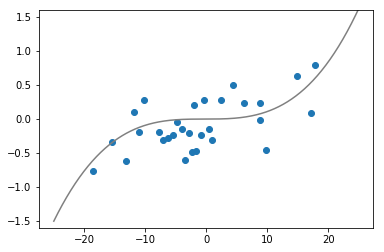

```python
# グラフを描画
plt.scatter(X, y)                         # データ点をプロット
plt.plot(X_plot, y_plot, color='gray')    # もととなる三次関数を描画
plt.ylim([-1.6, 1.6])                     # 縦の表示範囲を指定
plt.show()                                # グラフを表示
```

#### 多項式回帰の実行

このデータに対して多項式回帰を行います｡**回帰式がもとの3次関数に近いものになれば､回帰分析は成功**となります｡しかし､今回はあえて過学習をさせるので､**7次関数**という高次の関数で回帰を行います｡

```python
from sklearn.linear_model import LinearRegression    # 線形回帰のクラス
from sklearn.preprocessing import PolynomialFeatures # 多項式変換のクラス
lr = LinearRegression()                              # 線形回帰のインスタンスを生成
pol = PolynomialFeatures(degree=7)                   # 7次関数用に特徴量を変換するインスタンスを生成
X_pol = pol.fit_transform(X)                         # Xを7次関数用に変換
lr.fit(X_pol, y)                                     # 変換したデータを学習させる
X_plot_pol = pol.fit_transform(X_plot)               # プロット用のデータも同様に変換
y_plot_pol = lr.predict(X_plot_pol)                  # プロット用のデータのyを予測
```

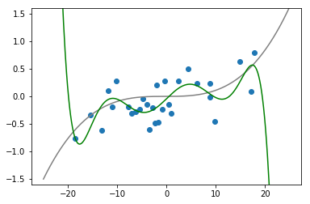

```python
# グラフを描画
plt.scatter(X, y)                                    # データ点をプロット
plt.plot(X_plot, y_plot, color='gray')               # もととなる三次関数を描画
plt.plot(X_plot, y_plot_pol, color='green')          # 通常の多項式回帰のモデルを描画
plt.ylim([-1.6, 1.6])                                # 縦の表示範囲を指定
plt.show()                                           # グラフを描画
```

想定の通りに過学習が起こりました｡ここからは､3種類の正則化によって過学習がどのように改善されていくのかを見ていきましょう｡

### 5.4.2 Ridge回帰

初めに紹介するのは､**L2ノルム**に罰則を課す**Ridge回帰**です｡ただし､scikit-learnでは､計算が簡潔になるという理由から､L2ノルムの**2乗**に罰則を課しています｡よって､scikit-learnによるRidge回帰の目的関数は以下のようになります｡

$$J(\boldsymbol{w})_{Ridge} = \sum^{n}_{i=0} \| y^{(i)}-\hat{y}^{(i)} \| ^2 + \lambda \|\boldsymbol{w}\|^2_2$$

[figure not shown]

#### Ridge回帰の実行

Ridge回帰はlinear_modelの**Ridge**クラスを利用して実行できます｡**alpha（正則化項の係数 $\lambda$ のこと）**の値を変えながら繰り返し実行してみましょう｡回帰係数や決定係数の出力はLinearRegressionと同様に.coef_や.scoreで出力できます｡

```python
# Ridge回帰を実行
# alphaとは､先ほど紹介したλのことです
from sklearn.linear_model import Ridge                        # Ridge回帰のクラスを読み込み
model_ridge = Ridge(alpha=1000)                               # Ridge回帰のインスタンスを生成
model_ridge.fit(X_pol, y)                                     # データを学習させる
```

```
Ridge(alpha=1000, copy_X=True, fit_intercept=True, max_iter=None,
   normalize=False, random_state=None, solver='auto', tol=0.001)
```

グラフによって可視化をしながら､Ridge回帰の効果を確認します｡

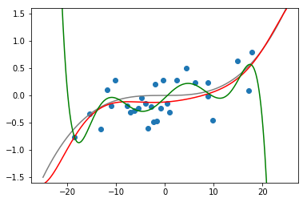

```python
# グラフを描画
plt.scatter(X, y)                                              # データ点をプロット
plt.plot(X_plot, y_plot, color='gray')                         # もととなる三次関数を描画
plt.plot(X_plot, model_ridge.predict(X_plot_pol), color='red') # Ridge回帰によるモデルを描画
plt.plot(X_plot, y_plot_pol, color='green')                    # 通常の多項式回帰のモデルを描画
plt.ylim([-1.6, 1.6])                                          # 縦の表示範囲を指定
plt.show()                                                     # グラフを描画
```

#### L2ノルムの縮小を確認

続いて､Ridge回帰によって**L2ノルムが縮小されていること**を確認します｡L2ノルムは､線形代数関連の関数をまとめたnumpyの**linalg**の**norm**メソッドで出力できます｡

$$\|\boldsymbol{w}\|_2 = \sqrt{w_1^2 + w_2^2 +...+ w_d^2}$$

```python
# 重みを出力（正則化なし）
lr.coef_
```

```
array([  0.00000000e+00,   8.65504973e-02,   4.11571234e-04,
        -1.64948411e-03,  -4.05575048e-06,   9.48940782e-06,
         5.18992808e-09,  -1.49851211e-08])
```

```python
# 重みを出力（Ridge回帰）
model_ridge.coef_
```

```
array([  0.00000000e+00,   6.00178293e-03,   1.35634933e-03,
         1.14754021e-06,  -5.17185214e-06,   4.16096324e-07,
         5.24302212e-09,  -4.29044302e-10])
```

```python
# L2ノルムの値を出力（正則化なし）
from numpy import linalg as LA
LA.norm(lr.coef_)
```

```
0.086567192885011676
```

```python
# L2ノルムの値を出力（Ridge回帰）
LA.norm(model_ridge.coef_)
```

```
0.0061531382276878233
```

以上の結果から､Ridge回帰がL2ノルムを縮小させていて､その結果予測精度が安定することが確認できました｡

### 5.4.3 LASSO

次に､**L1ノルム**に罰則を課す**LASSO**です｡LASSOの目的関数が以下のようになります｡

$$J(\boldsymbol{w})_{LASSO} = \frac{1}{2n} \sum^{n}_{i=0} (y^{(i)}-\hat{y}^{(i)})^2 + \lambda\sum^{m}_{j=1} |w_j|$$

[figure not shown]

#### 自動的な特徴選択

特徴選択とは､**学習に必要な特徴量を選別して利用すること**です｡また､利用する特徴量を減らすこと全般を**次元削減**と言います｡LASSOの最大の特徴は､**特徴選択による次元削減を自動的に行えること**です｡そもそも､LASSOというのが**"Least Absolute Shrinkage and Selection Operator（選択的な縮小推定器）"**の略なのです｡**｢縮小推定器｣**は**パラメータ値による影響を小さくしようとする正則化**のを､**｢選択的な｣**はモデルの中で､**不要と思われる特徴量を選択して消去する**という意味です｡

[figure not shown]

LASSOに特徴選択ができる理由は､**L1ノルムの等高線のとがった形状**にあります｡L1ノルムに罰則を課したとき､**最適解は等高線の正方形の角に落ち着くことが多くなります**｡下図にあるRidge回帰との比較を見ると､それが確認できます｡そして､正方形の角は**座標軸上**にありますので､**このとき何かしらのパラメータの値は0になります**｡パラメータが0になるということは､ $w_ix_i = 0 \times x_i = 0$ となり､**掛け算されている特徴量が回帰式から消去される**ことになります｡

これにより､**重要でない特徴量は次々に消去されていきます**｡このようにすると､最適解となる重みベクトルの要素には0が多くなります｡このような解を**疎な解（Sparse Solution）**と呼びます｡重要な特徴量だけが生き残り､それらによってのみ予測を行うモデルがつくられるのです｡

[figure not shown]

#### LASSOの使い所

LASSOの性質が最も活かされるのは､**スパースなデータを分析するとき**です｡スパースなデータでは､**サンプル数に対して特徴量が多すぎる**という問題が多くつきまといます｡これによって､モデルが過学習をしやすくなってしまいます｡その中には**分析にほとんど貢献しない特徴量**もあり､LASSOによる特徴選択が有効です｡また､膨大な特徴量に対しての判別が自動的に行われるという点も非常にありがたいものです｡

[figure not shown]

#### LASSOの実行

LASSOは､linear_modelの**Lasso**クラスを利用して実行できます｡Ridge回帰と同様に､**alpha**の値を変えながらグラフを観察します｡

```python
# LASSO回帰を実行
from sklearn.linear_model import Lasso                         # LASSO回帰のクラスを読み込み
model_lasso = Lasso(alpha=1000)                                # LASSO回帰のインスタンスを生成
model_lasso.fit(X_pol, y)                                      # データを学習させる
```

```
Lasso(alpha=1000, copy_X=True, fit_intercept=True, max_iter=1000,
   normalize=False, positive=False, precompute=False, random_state=None,
   selection='cyclic', tol=0.0001, warm_start=False)
```

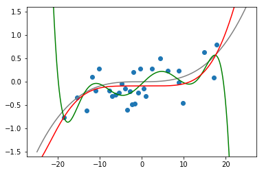

```python
# グラフを描画する
plt.scatter(X, y)                                              # データ点をプロット
plt.plot(X_plot, y_plot, color='gray')                         # もととなる三次関数を描画
plt.plot(X_plot, y_plot_pol, color='green')                    # 通常の多項式回帰によるモデルを描画
plt.plot(X_plot, model_lasso.predict(X_plot_pol), color='red') # LASSO回帰によるモデルを描画
plt.ylim([-1.6, 1.6])                                          # 縦の表示範囲を指定
plt.show()                                                     # グラフを描画
```

#### L1ノルムと次元削減を確認

LASSOにおいては､パラメータについて確認することが2つあります｡

- **特徴選択による次元削減**
- **L1ノルムの縮小**

特徴選択が正常に行われていれば､**重みベクトルの成分のいくつかは0になっていること**が見込まれます｡また､L1ノルムは､linalgのnormメソッドで**ord=1**と引数を指定して実行することで出力できます｡ordは**Lpノルムの種類を指定する引数**です｡

$$\|\boldsymbol{w}\|_1 = |w_1| + |w_2| +...+ |w_d|$$

```python
# 重みを出力（正則化なし）
lr.coef_
```

```
array([  0.00000000e+00,   8.65504973e-02,   4.11571234e-04,
        -1.64948411e-03,  -4.05575048e-06,   9.48940782e-06,
         5.18992808e-09,  -1.49851211e-08])
```

```python
# 重みを出力（LASSO）
model_lasso.coef_
```

```
array([  0.00000000e+00,   0.00000000e+00,   0.00000000e+00,
         0.00000000e+00,   0.00000000e+00,   4.84889999e-07,
         2.03058492e-09,  -4.20064051e-10])
```

8つのパラメータのうち､5つが0になっています｡このことから､LASSOによる次元削減が確認できました｡

```python
# L1ノルムを確認（正則化なし）
LA.norm(lr.coef_, ord=1)
```

```
0.088625118011573925
```

```python
# L1ノルムを確認（LASSO）
LA.norm(model_lasso.coef_, ord=1)
```

```
4.8734064792308564e-07
```

加えて､L1ノルムの縮小も確認できました｡

### 5.4.4 Elastic Net

最後に､**L2とL1の中間のノルム**に罰則を課す**ElasticNet**を紹介します｡ElasticNetの目的関数は､以下に示すような**L1ノルムとL2ノルムの両方に同時に罰則を課す構造**になっています｡両者の係数 **$\lambda_1$** と **$\lambda_2$** を調整して両者のバランスをとり､中間のノルムへの罰則を再現します｡

$$J(\boldsymbol{w})_{ElasticNet} = \frac{1}{2n} \sum^{n}_{i=0} ( y^{(i)}-\hat{y}^{(i)} ) ^2 + \lambda_1 \sum^{m}_{j=1} |w_j| + \lambda _2 \|\boldsymbol{w}\|^2 $$

[figure not shown]

また､scikit-learnではこの式が以下のように変形されています｡一番のポイントは､**ハイパーパラメータのとり方が変わったこと**です｡変形前の式では $\lambda _1$ と $\lambda _2$ を使用していましたが､変形後は **$\alpha$** と **$L_1 ratio$** を利用しています｡

$$ElasticNet = \frac{1}{2n} \sum^{n}_{i=0} (y^{(i)}-\hat{y}^{(i)})^2 + \alpha *L_1ratio\sum^{m}_{j=1} |w_j| + \frac{1}{2} \alpha* (1 - L_1ratio) \|\boldsymbol{w}\|^2 $$

置き換えた理由は､**ハイパーパラメータを解釈しやすくするため**です｡変形後の式では **$\alpha$ で正則化全体の強さを､$L_1ratio$ でノルムをどの程度L1に近くあるいはL2に近いものにするかを調整することができます**｡このような切り分け方でハイパーパラメータを設定すると､後の微調整がしやすくなるのです｡また､ $L_1 ratio$ は比率ですので､**0~1の範囲に値を収める必要があります**｡

#### 次元削減の強さを微調整

ElasticNetは､**次元削減の強さを微調整するために設計されました**｡L2ノルムとL1ノルムの中間のノルムに罰則を課すと､**次元削減の効果もRidge回帰とLASSOの中間の強さになります**｡Ridge回帰より強いがLASSOより弱い次元削減が行われるため､**次元削減をさせたいがLASSOでは効果が強すぎるという場合**に役立つのです｡ $L_1 ratio$ を微調整することで､**次元削減の強さを微調整することができます**｡

[figure not shown]

#### ElasticNetの実行

alphaとl1_ratioを調整しながら､適切なパラメータを探していきます｡

```python
# ElasticNetを実行
from sklearn.linear_model import ElasticNet                 # ElasticNetのクラスを読み込み
model_en= ElasticNet(alpha=1000, l1_ratio=0.9)              # ElasticNetのインスタンスを生成
model_en.fit(X_pol, y)                                      # データを学習させる
```

```
ElasticNet(alpha=1000, copy_X=True, fit_intercept=True, l1_ratio=0.9,
      max_iter=1000, normalize=False, positive=False, precompute=False,
      random_state=None, selection='cyclic', tol=0.0001, warm_start=False)
```

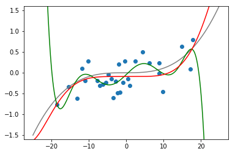

```python
# グラフを描画
plt.scatter(X, y)                                           # データ点をプロット
plt.plot(X_plot, y_plot, color='gray')                      # もととなる三次関数を描画
plt.plot(X_plot, y_plot_pol, color='green')                 # 通常の多項式回帰によるモデルを描画
plt.plot(X_plot, model_en.predict(X_plot_pol), color='red') # ElasticNetによるモデルを描画
plt.ylim([-1.6, 1.6])                                       # 縦の表示範囲を指定
plt.show()                                                  # グラフを描画
```

ElasticNetはL1とL2両方のノルムに罰則を課しているので､両方のノルムについて縮小を確認します｡

```python
# 重みを出力（正則化なし）
lr.coef_
```

```
array([  0.00000000e+00,   8.65504973e-02,   4.11571234e-04,
        -1.64948411e-03,  -4.05575048e-06,   9.48940782e-06,
         5.18992808e-09,  -1.49851211e-08])
```

```python
# 重みを出力（ElasticNet）
model_en.coef_
```

```
array([  0.00000000e+00,   0.00000000e+00,   0.00000000e+00,
         0.00000000e+00,   0.00000000e+00,   5.00299266e-07,
         1.98532010e-09,  -4.68508620e-10])
```

次元削減が行われていることが確認できました｡

```python
# L2ノルムの値を出力（正則化なし）
from numpy import linalg as LA
LA.norm(lr.coef_)
```

```
0.086567192885011676
```

```python
# L2ノルムの値を出力（ElasticNet）
LA.norm(model_en.coef_)
```

```
5.0030342442003446e-07
```

```python
# L1ノルムを確認（通常の多項式回帰）
LA.norm(lr.coef_, ord=1)
```

```
0.088625118011573925
```

```python
# L1ノルムを確認（ElasticNet）
LA.norm(model_en.coef_, ord=1)
```

```
5.0275309464862551e-07
```

L2､L1の両方とも縮小されていることが確認できました｡

[figure not shown]

監修: 東京女子大学情報処理センター 浅川伸一